# Simple Linear Regression

Hillary

1/21/2020

### Introduction

Simple Linear regression is used to predict the value of an outcome variable Y based on one input predictor variable X. The aim is to establish a linear relationship between the predictor variable and the response variable, so that, we can use this formula to estimate the value of the response Y, when only the predictor (X) values are known. For this example we will use the ‘cars’ dataset.

```r
head(cars)  # display the first 6 observations
```

```
##   speed dist
## 1     4    2
## 2     4   10
## 3     7    4
## 4     7   22
## 5     8   16
## 6     9   10
```

# Outline

- Graphical Analysis
- Correlation
- Build Linear Model
- Model Diagnostics
- Machine learning

# Graphical Analysis

- Scatter plot: Visualize the linear relationship between the predictor and response.
- Box plot: To spot any outlier observations in the variable. Having outliers in your predictor can drastically affect the predictions as they can easily affect the direction/slope of the line of best fit.
- Density plot: To see the distribution of the predictor variable. Ideally, a close to normal distribution (a bell shaped curve), without being skewed to the left or right is preferred. Let us see how to make each one of them.

# Scatter plot

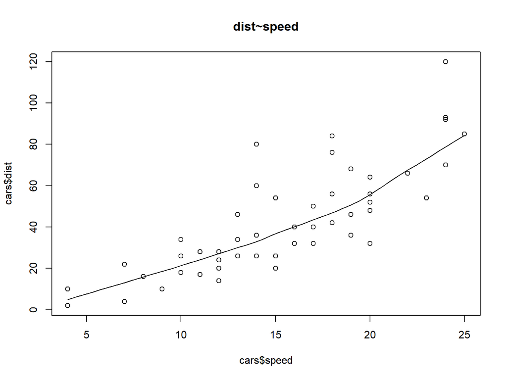

```r
# Visualize the relationship between response and predictor
scatter.smooth(x=cars$speed,y=cars$dist,main="dist~speed")
```

# Box plot

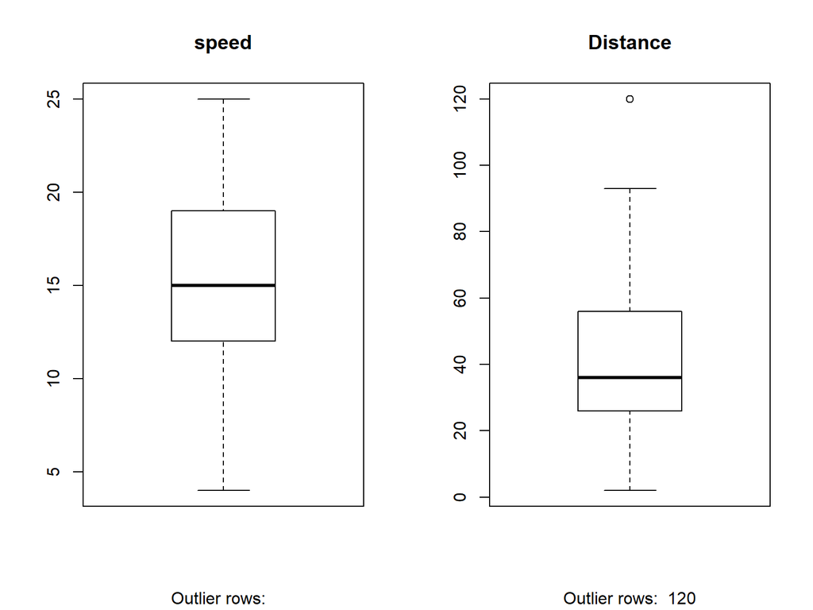

```r
# Spot any outlier that might affect the direction of the slope
par(mfrow=c(1,2))
boxplot(cars$speed,main="speed",sub=paste("Outlier rows: ",
        boxplot.stats(cars$speed)$out))
boxplot(cars$dist,main="Distance",sub=paste("Outlier rows: ",
              boxplot.stats(cars$dist)$out))
```

# Density plot

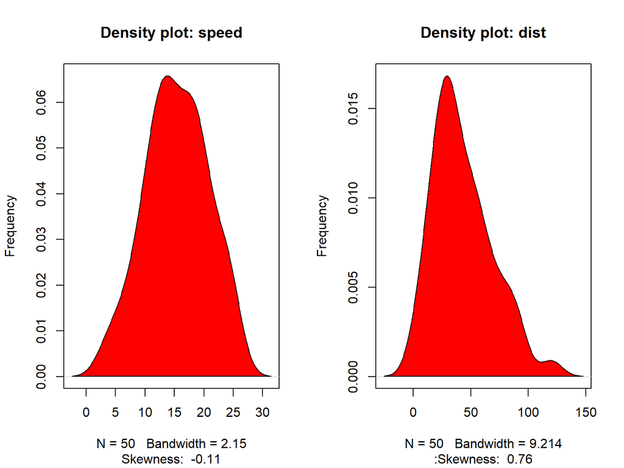

```r
library(e1071)
par(mfrow=c(1,2))
plot(density(cars$speed),main="Density plot: speed",ylab="Frequency",
sub=paste("Skewness: ",round(e1071::skewness(cars$speed),2)))
polygon(density(cars$speed),col="red")
plot(density(cars$dist),main="Density plot: dist",ylab = "Frequency",
sub=paste(":Skewness: ",round(e1071::skewness(cars$dist),2)))
polygon(density(cars$dist),col = "red")
```

# Correlation

- This measure will show the level of linear dependence between response and predictor variable.
- A value closer to 0 suggests a weak relationship between the variables, while a value closer to 1 suggests strong relationship. A low correlation (-0.2 < x < 0.2) probably suggests that much of variation of the response variable (Y) is unexplained by the predictor (X), in which case, we should probably look for better explanatory variables.

```r
cor(cars$speed,cars$dist)
```

```
## [1] 0.8068949
```

# Build Linear model

Now, we have to establish the mathematical relationship between response and predictor variable using the beta coefficient and the intercept to for the simple linear equation: dist = Intercept + (β∗speed)

```r
LinearMod=lm(cars$dist~cars$speed)
LinearMod
```

```
##
## Call:
## lm(formula = cars$dist ~ cars$speed)
##
## Coefficients:
## (Intercept)   cars$speed
##     -17.579        3.932
```

# Model Diagnostics

Here, we have to ensure the model is statistically significant, by checking the size of the p-value, t-value, f-statistic, R-squared, Adjusted R-squared, AIC,BIC Mean Absolute Percentage Error (MAPE), Mean Squared Error (MSE)

```r
modelSummary=summary(LinearMod)
modelSummary #whole model diagnostic
```

```
##
## Call:
## lm(formula = cars$dist ~ cars$speed)
##
## Residuals:
##     Min      1Q  Median      3Q     Max
## -29.069  -9.525  -2.272   9.215  43.201
##
## Coefficients:
##             Estimate Std. Error t value Pr(>|t|)
## (Intercept) -17.5791     6.7584  -2.601   0.0123 *
## cars$speed    3.9324     0.4155   9.464 1.49e-12 ***
## ---
## Signif. codes:  0 '***' 0.001 '**' 0.01 '*' 0.05 '.' 0.1 ' ' 1
##
## Residual standard error: 15.38 on 48 degrees of freedom
## Multiple R-squared:  0.6511, Adjusted R-squared:  0.6438
## F-statistic: 89.57 on 1 and 48 DF,  p-value: 1.49e-12
```

```r
#Break down of indiviadual elements
names(modelSummary) #view the objects in the model
```

```
##  [1] "call"          "terms"         "residuals"     "coefficients"
##  [5] "aliased"       "sigma"         "df"            "r.squared"
##  [9] "adj.r.squared" "fstatistic"    "cov.unscaled"
```

```r
modelCoeffs=modelSummary$coefficients #model coefficients
modelCoeffs
```

```
##               Estimate Std. Error   t value     Pr(>|t|)
## (Intercept) -17.579095  6.7584402 -2.601058 1.231882e-02
## cars$speed    3.932409  0.4155128  9.463990 1.489836e-12
```

```r
beta_estimate <-modelCoeffs[2,1]  # get beta estimate for speed
beta_estimate
```

```
## [1] 3.932409
```

```r
std.error <-modelCoeffs[2,2]  # Closer to zero the better
std.error
```

```
## [1] 0.4155128
```

```r
MSE<-(std.error)^2 #get mse for speed
MSE
```

```
## [1] 0.1726509
```

```r
t_value <- beta_estimate/std.error #Should be greater 1.96 for p-value to be less than 0.05
t_value
```

```
## [1] 9.46399
```

```r
p_value <- 2*pt(-abs(t_value), df=nrow(cars)-ncol(cars))  # calc p Value
p_value
```

```
## [1] 1.489836e-12
```

```r
f_statistic <- modelSummary$fstatistic  # parameters for model p-value calc
f_statistic
```

```
##    value    numdf    dendf
## 89.56711  1.00000 48.00000
```

```r
R_squared<-modelSummary$r.squared #Higher the better (> 0.70)
R_squared
```

```
## [1] 0.6510794
```

```r
adj_R_squared<-modelSummary$adj.r.squared #Higher the better (> 0.70)
adj_R_squared
```

```
## [1] 0.6438102
```

```r
AIC(LinearMod)  #Lower the better
```

```
## [1] 419.1569
```

```r
BIC(LinearMod) #Lower the better
```

```
## [1] 424.8929
```

# Machine learning

- Create a training and a test data
- Build the model on training data
- Model evaluation: Review diagnostic measures
- Model testing: Calculate prediction accuracy and error rates

# Create a training and a test data

```r
#Create Training and Test data
set.seed(100)  # setting seed to reproduce results of random sampling
trainingRowIndex <- sample(1:nrow(cars), 0.8*nrow(cars))# row indices for training data
trainingData <- cars[trainingRowIndex, ]  # model training data
dim(trainingData)
```

```
## [1] 40  2
```

```r
testData  <- cars[-trainingRowIndex, ]# test data
dim(testData)
```

```
## [1] 10  2
```

# Build the model on training data

```r
lmMod <- lm(dist ~ speed, data=trainingData)  # build the model
lmMod
```

```
##
## Call:
## lm(formula = dist ~ speed, data = trainingData)
##
## Coefficients:
## (Intercept)        speed
##     -20.180        4.258
```

```r
distPred <- predict(lmMod, testData)  # predict distance
head(distPred)
```

```
##         3         5        17        24        28        32
##  9.627845 13.886057 35.177120 43.693545 47.951757 56.468182
```

# Model evaluation: Review diagnostic measures

```r
summary(lmMod)
```

```
##
## Call:
## lm(formula = dist ~ speed, data = trainingData)
##
## Residuals:
##     Min      1Q  Median      3Q     Max
## -24.726 -11.242  -2.564  10.436  40.565
##
## Coefficients:
##             Estimate Std. Error t value Pr(>|t|)
## (Intercept) -20.1796     7.8254  -2.579   0.0139 *
## speed         4.2582     0.4947   8.608 1.85e-10 ***
## ---
## Signif. codes:  0 '***' 0.001 '**' 0.01 '*' 0.05 '.' 0.1 ' ' 1
##
## Residual standard error: 15.49 on 38 degrees of freedom
## Multiple R-squared:  0.661,  Adjusted R-squared:  0.6521
## F-statistic: 74.11 on 1 and 38 DF,  p-value: 1.848e-10
```

# Model testing: Calculate prediction accuracy

```r
actuals_preds <- data.frame(cbind(actuals=testData$dist, predicteds=distPred))  # make actuals_predicteds dataframe.
correlation_accuracy <- cor(actuals_preds)
head(actuals_preds)
```

```
##    actuals predicteds
## 3        4   9.627845
## 5       16  13.886057
## 17      34  35.177120
## 24      20  43.693545
## 28      40  47.951757
## 32      42  56.468182
```

Min-max accuracy and Mean absolute percentage error

```r
min_max_accuracy <- mean(apply(actuals_preds, 1, min)/apply(actuals_preds, 1, max))
min_max_accuracy
```

```
## [1] 0.7311131
```

```r
mape <- mean(abs((actuals_preds$predicteds-actuals_preds$actuals))/actuals_preds$actuals)
mape
```

```
## [1] 0.4959096
```